# Reducción de datos con conjunto de datos Titanic

Juan Gómez Romero

Reducción de datos con el dataset [titanic](https://www.kaggle.com/c/titanic/).

**En este cuaderno ampliaremos el código desarrollado en titanic.Rmd para seleccionar automáticamente las variables que se utilizarán para construir el modelo de predicción.**

Para ello, nos basaremos en la premisa de que diversos algoritmos de [`caret`](http://topepo.github.io/caret/) [ya incluyen procedimientos para selección de variables](https://topepo.github.io/caret/feature-selection-overview.html#builtin). Para un ejemplo detallado basado en uso de correlaciones entre variables, ver [aquí](https://github.com/jgromero/sige2020/tree/master/Pr%C3%A1cticas/01%20Selecci%C3%B3n%20de%20variables).

**Índice**

- 1. Preprocesamiento de datos
- 2. Creación de modelo predictivo
- 3. Importancia de las variables con modelo de predicción
- 4. Importancia de las variables sin modelo de predicción
- 5. Entrenamiento del modelo con selección de variables

# 1. Preprocesamiento de datos

Comenzamos leyendo el fichero de datos:

```r
library(tidyverse)
data_raw <- read_csv('train.csv')
head(data_raw)
```

```
## # A tibble: 6 x 12
##   PassengerId Survived Pclass Name  Sex     Age SibSp Parch Ticket  Fare
##         <dbl>    <dbl>  <dbl> <chr> <chr> <dbl> <dbl> <dbl> <chr>  <dbl>
## 1           1        0      3 Brau… male     22     1     0 A/5 2…  7.25
## 2           2        1      1 Cumi… fema…    38     1     0 PC 17… 71.3
## 3           3        1      3 Heik… fema…    26     0     0 STON/…  7.92
## 4           4        1      1 Futr… fema…    35     1     0 113803 53.1
## 5           5        0      3 Alle… male     35     0     0 373450  8.05
## 6           6        0      3 Mora… male     NA     0     0 330877  8.46
## # … with 2 more variables: Cabin <chr>, Embarked <chr>
```

A continuación, preprocesamos los datos para quedarnos con las variables que vamos a utilizar y recodificar la variable objetivo *Survived*. Las filas con valores NA se excluyen del proceso:

```r
# Datos con imputacion de valores perdidos
data <-
  data_raw %>%
  mutate(Survived = as.factor(ifelse(Survived == 1, 'Yes', 'No'))) %>%
  mutate(Pclass = as.factor(Pclass)) %>%
  select(Survived, Pclass, Sex, Age, SibSp, Parch, Fare, Embarked) %>%
  na.exclude()
```

# 2. Creación de modelo predictivo

Una vez están listos los datos, podemos crear un modelo predictivo que evalúa la importancia de las variables, como por ejemplo `rpart`.

### Entrenamiento

Creamos el modelo predictivo:

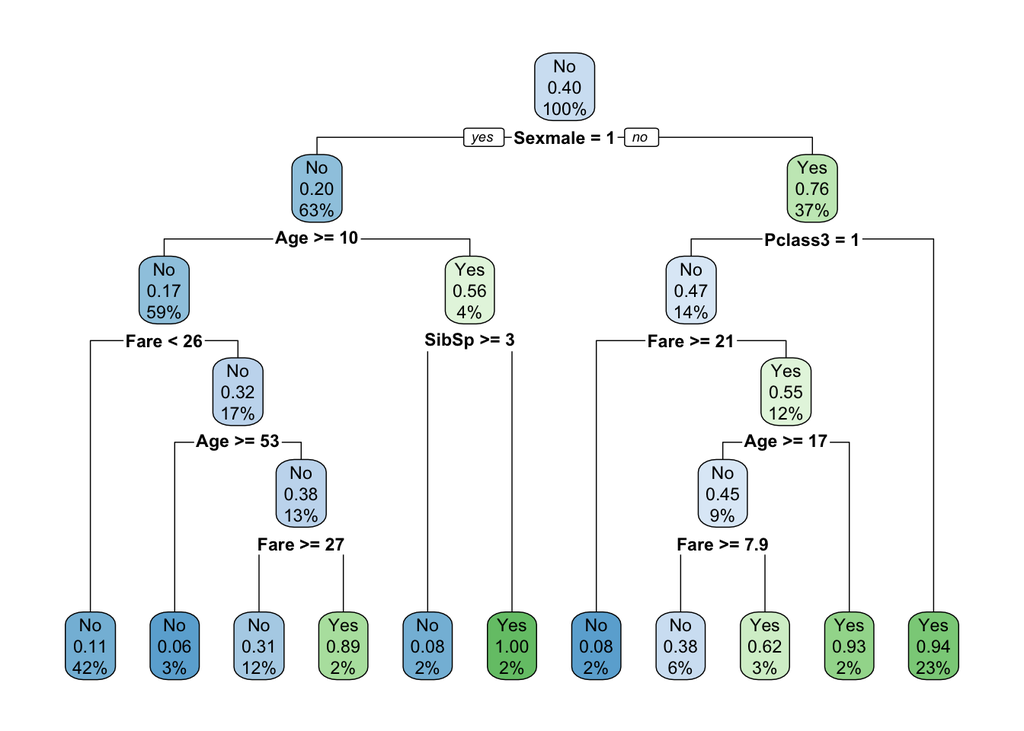

```r
# Parámetros
rpartCtrl <- trainControl(verboseIter = F, classProbs = TRUE, summaryFunction = twoClassSummary)
rpartParametersGrid <- expand.grid(.cp = c(0.01, 0.05))

# Conjuntos de entrenamiento y validación
trainIndex <- createDataPartition(data$Survived, p = .8, list = FALSE, times = 1)
train <- data[trainIndex, ]

# Entrenamiento del modelo
rpartModel <- train(Survived ~ .,
                    data = train,
                    method = "rpart",
                    metric = "ROC",
                    trControl = rpartCtrl,
                    tuneGrid = rpartParametersGrid)

# Visualización del modelo
rpart.plot(rpartModel$finalModel)
```

### Validación

Obtenemos resultados con el conjunto de validación:

```r
# Predicciones con clases
val        <- data[-trainIndex, ]
prediction <- predict(rpartModel, val, type = "raw")

# Predicciones con probabilidades
predictionValidationProb <- predict(rpartModel, val, type = "prob")
```

Y calculamos las métricas de calidad del clasificador (matriz de confusión y curva ROC):

```r
cm_train <- confusionMatrix(prediction, val[["Survived"]])
cm_train
```

```
## Confusion Matrix and Statistics
##
##           Reference
## Prediction No Yes
##        No  79  21
##        Yes  5  36
##
##                Accuracy : 0.8156
##                  95% CI : (0.7416, 0.8759)
##     No Information Rate : 0.5957
##     P-Value [Acc > NIR] : 1.91e-08
##
##                   Kappa : 0.5991
##  Mcnemar's Test P-Value : 0.003264
##
##             Sensitivity : 0.9405
##             Specificity : 0.6316
##          Pos Pred Value : 0.7900
##          Neg Pred Value : 0.8780
##              Prevalence : 0.5957
##          Detection Rate : 0.5603
##    Detection Prevalence : 0.7092
##       Balanced Accuracy : 0.7860
##
##        'Positive' Class : No
##
```

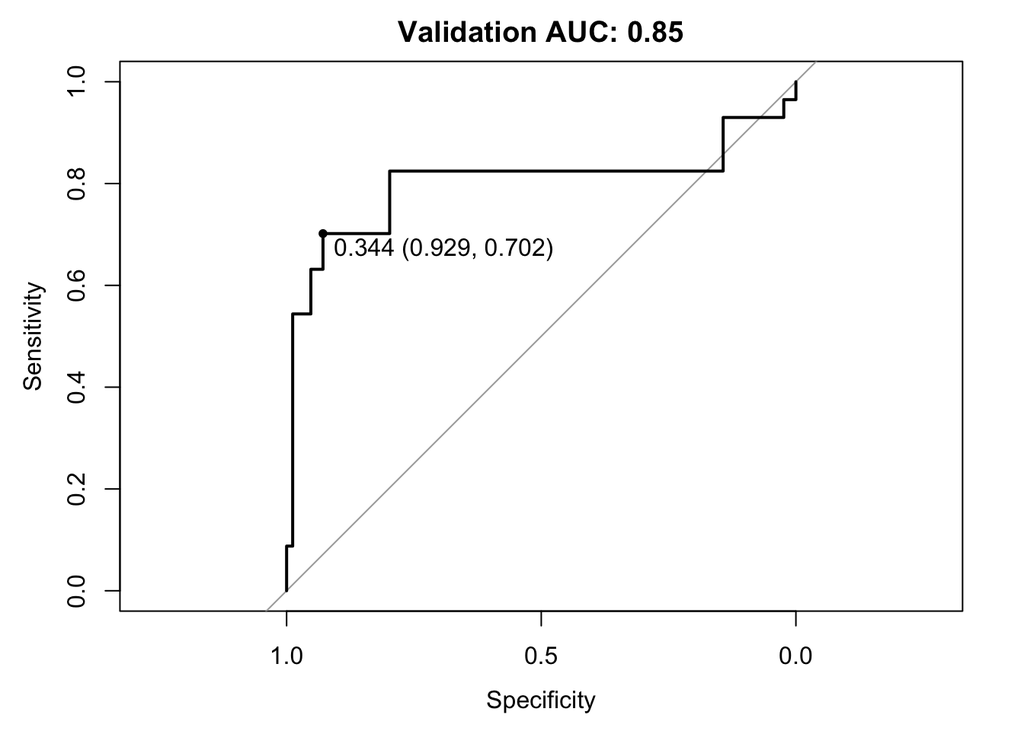

```r
auc <- roc(val$Survived, predictionValidationProb[["Yes"]], levels = unique(val[["Survived"]]))
roc_validation <- plot.roc(auc,
                           ylim=c(0,1),
                           type = "S" ,
                           print.thres = TRUE,
                           main=paste('Validation AUC:', round(auc$auc[[1]], 2)))
```

### Otros modelos de predicción

Otro modelo de predicción que calcula importancia de variables es `rf`:

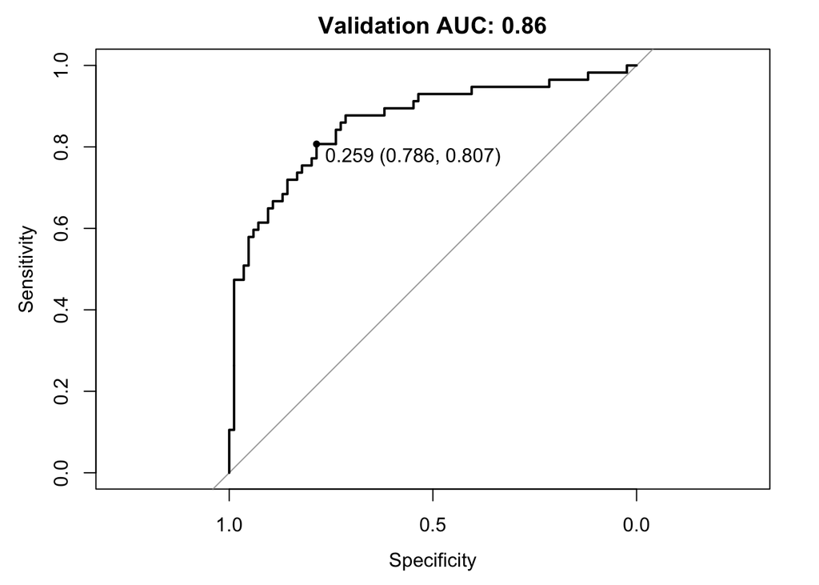

```r
rfModel <- train(Survived ~ ., data = train, method = "rf", metric = "ROC", trControl = rpartCtrl)
predictionValidationProb <- predict(rfModel, val, type = "prob")
auc <- roc(val$Survived, predictionValidationProb[["Yes"]], levels = unique(val[["Survived"]]))
roc_validation <- plot.roc(auc,
                           ylim=c(0,1),
                           type = "S" ,
                           print.thres = TRUE,
                           main=paste('Validation AUC:', round(auc$auc[[1]], 2)))
```

# 3. Importancia de las variables con modelo de predicción

Una vez que los modelos han sido entrenados, podemos estudiar la importancia que cada otorga a las variabales utilizando [`varImp`](https://topepo.github.io/caret/variable-importance.html) en [`caret`](http://topepo.github.io/caret/):

```r
varImp(rpartModel)
```

```
## rpart variable importance
##
##           Overall
## Sexmale    100.00
## Fare        74.45
## Pclass3     71.29
## Age         32.44
## Parch       22.41
## SibSp       19.66
## Pclass2     16.56
## EmbarkedS   15.77
## EmbarkedQ    0.00
```

```r
varImp(rfModel)
```

```
## rf variable importance
##
##           Overall
## Sexmale   100.000
## Fare       54.651
## Age        44.300
## Pclass3    27.853
## Parch      12.244
## SibSp      11.713
## EmbarkedS   5.820
## Pclass2     5.082
## EmbarkedQ   0.000
```

El ranking obtenido puede servir para seleccionar las variables que se utilizarán para abordar el problema; por ejemplo aquellas con valor *Overall* por encima de 25. Esta selección se puede automatizar parcialmente, ya que tanto `rpart` como `rf` usan variables ‘dummy’ (por ejemplo, *Sexmale*) que no están en el dataset original.

```r
important_vars <- varImp(rfModel)$importance %>%
  rownames_to_column() %>%
  filter(Overall > 25) %>%
  select(rowname)
```

El orden de importancia se corresponden aproximadamente con el valor absoluto de correlación entre cada variable y la variable objetivo:

```r
# correlation_table(data, target='Survived')
data_num <-
  data %>%
  mutate_if(is.character, as.factor) %>%
  mutate_if(is.factor, as.numeric)
cor(data_num)
```

```
##             Survived      Pclass         Sex         Age       SibSp
## Survived  1.00000000 -0.35646159 -0.53676162 -0.08244587 -0.01552302
## Pclass   -0.35646159  1.00000000  0.15082621 -0.36590186  0.06518706
## Sex      -0.53676162  0.15082621  1.00000000  0.09903723 -0.10629611
## Age      -0.08244587 -0.36590186  0.09903723  1.00000000 -0.30735094
## SibSp    -0.01552302  0.06518706 -0.10629611 -0.30735094  1.00000000
## Parch     0.09526529  0.02366612 -0.24954273 -0.18789649  0.38333753
## Fare      0.26609960 -0.55289322 -0.18245683  0.09314252  0.13986049
## Embarked -0.18197934  0.24414499  0.10963900 -0.03256492  0.03306447
##                Parch        Fare    Embarked
## Survived  0.09526529  0.26609960 -0.18197934
## Pclass    0.02366612 -0.55289322  0.24414499
## Sex      -0.24954273 -0.18245683  0.10963900
## Age      -0.18789649  0.09314252 -0.03256492
## SibSp     0.38333753  0.13986049  0.03306447
## Parch     1.00000000  0.20662367  0.01180289
## Fare      0.20662367  1.00000000 -0.28351044
## Embarked  0.01180289 -0.28351044  1.00000000
```

Visualmente, podemos verlo como tabla de correlación o como mapa de calor:

```r
rcorr(as.matrix(data_num))
```

```
##          Survived Pclass   Sex   Age SibSp Parch  Fare Embarked
## Survived     1.00  -0.36 -0.54 -0.08 -0.02  0.10  0.27    -0.18
## Pclass      -0.36   1.00  0.15 -0.37  0.07  0.02 -0.55     0.24
## Sex         -0.54   0.15  1.00  0.10 -0.11 -0.25 -0.18     0.11
## Age         -0.08  -0.37  0.10  1.00 -0.31 -0.19  0.09    -0.03
## SibSp       -0.02   0.07 -0.11 -0.31  1.00  0.38  0.14     0.03
## Parch        0.10   0.02 -0.25 -0.19  0.38  1.00  0.21     0.01
## Fare         0.27  -0.55 -0.18  0.09  0.14  0.21  1.00    -0.28
## Embarked    -0.18   0.24  0.11 -0.03  0.03  0.01 -0.28     1.00
##
## n= 712
##
##
## P
##          Survived Pclass Sex    Age    SibSp  Parch  Fare   Embarked
## Survived          0.0000 0.0000 0.0278 0.6792 0.0110 0.0000 0.0000
## Pclass   0.0000          0.0000 0.0000 0.0822 0.5284 0.0000 0.0000
## Sex      0.0000   0.0000        0.0082 0.0045 0.0000 0.0000 0.0034
## Age      0.0278   0.0000 0.0082        0.0000 0.0000 0.0129 0.3856
## SibSp    0.6792   0.0822 0.0045 0.0000        0.0000 0.0002 0.3783
## Parch    0.0110   0.5284 0.0000 0.0000 0.0000        0.0000 0.7532
## Fare     0.0000   0.0000 0.0000 0.0129 0.0002 0.0000        0.0000
## Embarked 0.0000   0.0000 0.0034 0.3856 0.3783 0.7532 0.0000
```

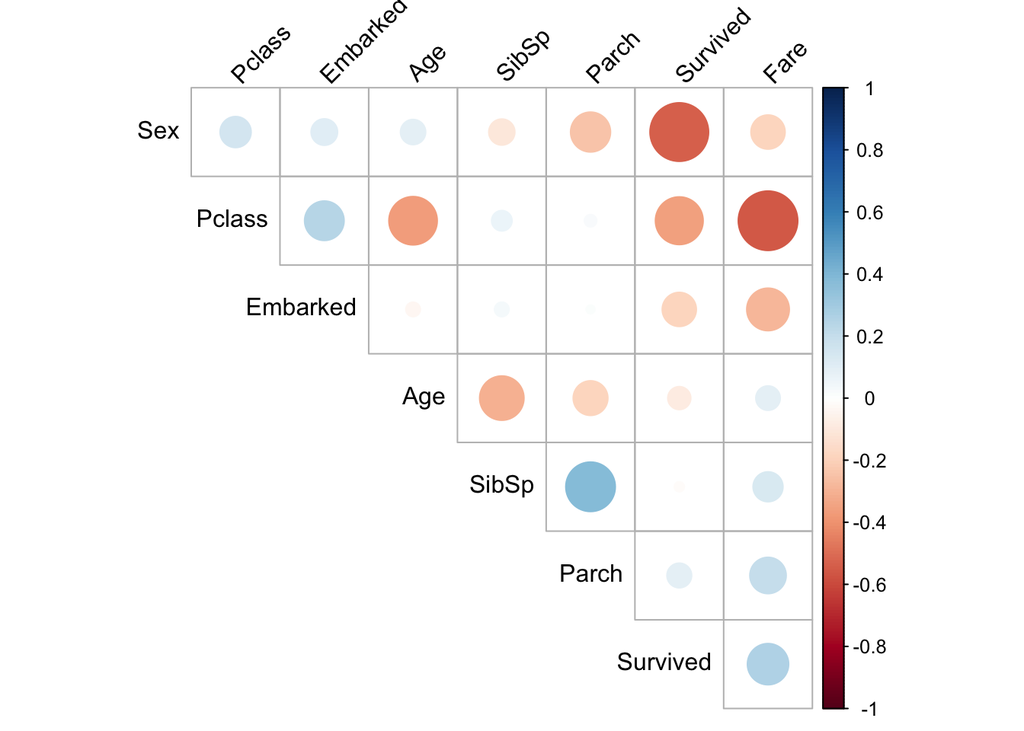

```r
corrplot(cor(data_num), type = "upper", diag = F, order = "hclust", tl.col = "black", tl.srt = 45)
```

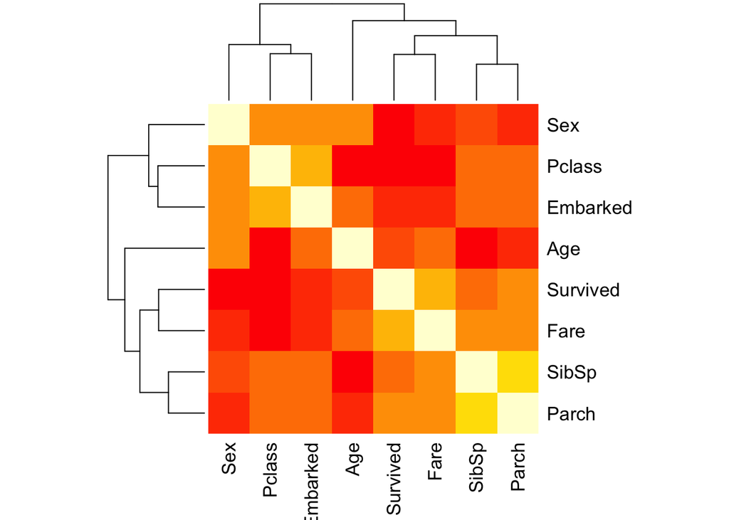

```r
heatmap(x = cor(data_num), symm = TRUE)
```

# 4. Importancia de las variables sin modelo de predicción

También se puede conocer la importancia de las variables sin crear explícitamente un modelo de predicción, sino simplemente calculando los mismos parámetros que se utilizan para aprender los modelos. Por ejemplo, los modelos de árboles utilizan la ganancia de información o la entropía para decidir sobre qué variables ramificar. Con var_rank_info podemos estimar varios estos valores directamente:

- en: entropy measured in bits
- mi: mutual information
- ig: information gain
- gr: gain ratio

```r
var_rank_info(data, "Survived")
```

```
##        var    en    mi         ig         gr
## 1      Sex 1.705 0.214 0.21410831 0.22638678
## 2     Fare 7.500 0.457 0.45650850 0.06537621
## 3   Pclass 2.381 0.094 0.09400998 0.06262926
## 4 Embarked 1.859 0.028 0.02785821 0.03050629
## 5    Parch 2.171 0.031 0.03068201 0.02498243
## 6      Age 6.680 0.127 0.12724736 0.02181265
## 7    SibSp 2.302 0.025 0.02486899 0.01836950
```

# 5. Entrenamiento del modelo con selección de variables

Una vez determinadas las variables importantes, podemos entrenar el modelo seleccionando solamente con estas:

```r
# Datos de entrenamiento
data_reduced <-
  data %>%
  select(Survived, Sex, Fare, Age, Pclass, SibSp)
head(data_reduced)
```

```
## # A tibble: 6 x 6
##   Survived Sex     Fare   Age Pclass SibSp
##   <fct>    <chr>  <dbl> <dbl> <fct>  <dbl>
## 1 No       male    7.25    22 3          1
## 2 Yes      female 71.3     38 1          1
## 3 Yes      female  7.92    26 3          0
## 4 Yes      female 53.1     35 1          1
## 5 No       male    8.05    35 3          0
## 6 No       male   51.9     54 1          0
```

```r
train <- data_reduced[trainIndex, ]
val   <- data_reduced[-trainIndex, ]

# rpart
rpartModel_2 <- train(Survived ~ ., data = train, method = "rpart", metric = "ROC", trControl = rpartCtrl, tuneGrid = rpartParametersGrid)
predictionValidationProb <- predict(rpartModel_2, val, type = "prob")
auc <- roc(val$Survived, predictionValidationProb[["Yes"]], levels = unique(val[["Survived"]]))
auc
```

```
##
## Call:
## roc.default(response = val$Survived, predictor = predictionValidationProb[["Yes"]],     levels = unique(val[["Survived"]]))
##
## Data: predictionValidationProb[["Yes"]] in 84 controls (val$Survived 1) < 57 cases (val$Survived 2).
## Area under the curve: 0.8496
```

```r
# rf
rfModel_2 <- train(Survived ~ ., data = train, method = "rf", metric = "ROC", trControl = rpartCtrl)
predictionValidationProb <- predict(rfModel_2, val, type = "prob")
auc <- roc(val$Survived, predictionValidationProb[["Yes"]], levels = unique(val[["Survived"]]))
auc
```

```
##
## Call:
## roc.default(response = val$Survived, predictor = predictionValidationProb[["Yes"]],     levels = unique(val[["Survived"]]))
##
## Data: predictionValidationProb[["Yes"]] in 84 controls (val$Survived 1) < 57 cases (val$Survived 2).
## Area under the curve: 0.8743
```